# Ciencias de Datos para Economía

## Introducción a Git

### Comandos básicos de Git

`git log`: Muetra todos los commit que se han realizado a un código. Esta sentencia nos muestra:

- Número asociado al commit
- Rama donde se efectuó
- Nombre de usuario
- Fecha
- Mensaje asociado al commit

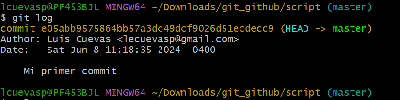

## Introducción a Git

### Agregando archivos y actualizandolos en Git

- Como sabemos, Git nos ayuda a gestionar versiones de archivos.
- Procederemos a crear un archivo en la carpeta donde hemos inicializado Git y luego lo gestionaremos.

  ```bash
  touch funciones_matematicas.py
  ```

- Luego procederemo en python a Crear la siguiente función:

  ```bash
  def fn_suma(a, b):
      total_suma = a + b
      return total_suma

  if __name__ == "__main__":
      # Ejemplo de uso de la función
      a = input('ingrese un numero ')
      b = input('ingrese otro numero ')
      resultado = fn_suma(int(a), int(b))  # Aquí puedes pasar los valores que desees
      print("La suma es:", resultado)
  ```

## Introducción a Git

### Agregando archivos y actualizandolos en Git

- Volvemos a generar un status de nuestro Git:

  ```bash
  git status
  ```

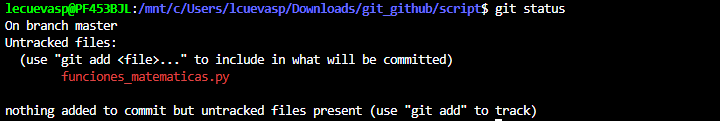

- Agregamos nuestro archivo a Git

  ```bash
  git add funciones_matematicas.py
  ```

## Introducción a Git

### Agregando archivos y actualizandolos en Git

- Realizamos un commit

  ```bash
  git commit -m "funcion suma"
  ```

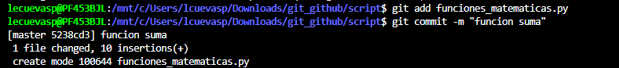

- Volvemos a generar un log de nuestro Git:

  ```bash
  git log
  ```

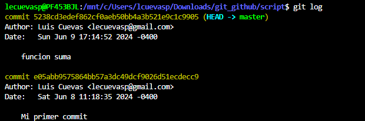

## Introducción a Git

### Modificando archivos y actualizandolos en Git

- Ahora modificaremos uno de los archivos de nuestro Git y volvemos a revisar su estatus:

  ```bash
  git status
  ```

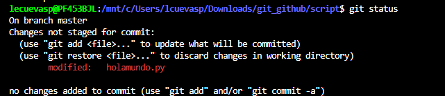

## Introducción a Git

### Modificando archivos y actualizandolos en Git

- Luego agregaremos el archivo a Git por medio de un commit agregando un comentario a la modificación realizada:

  ```bash
  git add holamundo.py
  git commit -m "Modificando hola mundo"
  ```

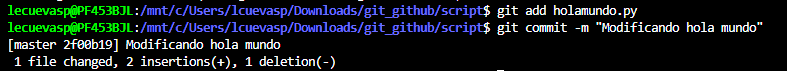

## Introducción a Git

### Reversando modificaciones de archivos en Git

- En Git podemos retroceder en el tiempo, es decir, volver a un commit anterior.
- Para esto tenemos dos opciones `git checkout HEAD~N°retroceder` o bien `git revert <commitID>`.
- `git checkout`: Por medio de esta sentencia Git procede a eliminar los commit posteriores al commit indicado.

## Introducción a Git

### Reversando modificaciones de archivos en Git

- `git revert`: En cambio por medio de esta sentencia, recuperamos el commit indicado y se guarda como un nuevo commit

  ```bash
  git revert <commitID>
  ```

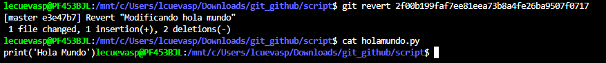

## Introducción a Git

### Mostrar nombre de archivos en Git

- `git diff-tree`: Permite conocer el nombre del archivo asociado al número de commit. Es decir, obtiene una lista de archivos que fueron modificados en un commit específico. Esta sentencia tiene la siguiente estructura:

  ```bash
  git diff-tree --no-commit-id --name-only -r <commitID>
  ```

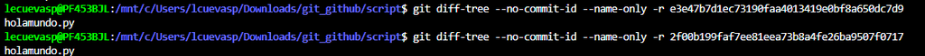

## Introducción a Git

### Mostrar nombre de archivos en Git

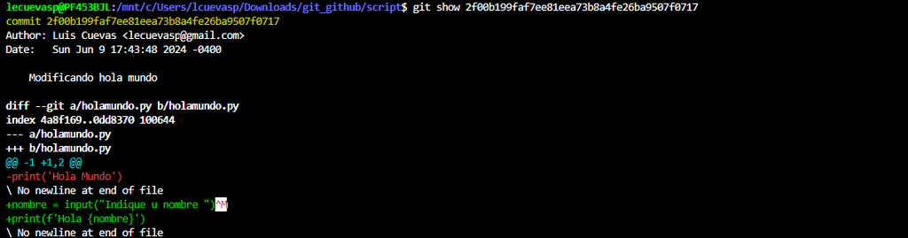

## Introducción a GitHub

## Introducción a GitHub

### ¿Qué es Github?

- GitHub es una plataforma donde puedes almacenar, compartir y trabajar junto con otros usuarios para escribir código.
- Almacenar tu código en un “repositorio” en GitHub te permite:
- Presentar o compartir el trabajo.
- Seguir y administrar los cambios en el código a lo largo del tiempo.
- Dejar que otros usuarios revisen el código y realicen sugerencias para mejorarlo.

## Introducción a GitHub

### ¿Qué es Github?

- Colaborar en un proyecto compartido, sin preocuparse de que los cambios afectarán al trabajo de los colaboradores antes de que esté listo para integrarlos.
- El trabajo colaborativo, una de las características fundamentales de GitHub, es posible gracias al software de código abierto Git, en el que se basa GitHub.

## Introducción a GitHub

### Crear cuenta en GitHub

- Ingresar al sitio web de GitHub: https://github.com
- Registrarse:
  - Indicar mail.
  - Crear Clave.
  - Ingrese Nombre de Usuario: Solo debe ser con caracteres alfanumérico y con guiones entre texto.
  - Recibirá al mail un código de 8 dígitos el cual debe indicarlo en GitHub.

## Introducción a GitHub

### Iniciar sesión

- Debes indicar usuario
- Contraseña

[figure not shown]

## Introducción a GitHub

### Conectar computador local con GitHub

- Se realiza por medio de SSH (llave pública y llaves privadas).
- Los pasos para generar estas llaves son los siguientes:
- `ls -al`: Lista todos los archivos y directorio de la carpeta donde se está posicionado, tanto de manera pública como privada.
- `.ssh`: Archivo que va a guardar todo lo generado a partir de llaves públicas y privadas que nos ayudan a conectarnos con GitHub.

  ```bash
  ls -al ~/.ssh
  ```

## Introducción a GitHub

### Conectar computador local con GitHub

- En caso que no aparezca dicho archivo en la raiz, se debe generar con esta sentencia

  ```bash
  mkdir -p ~/.ssh
  ```

- Luego aplicamos `ls -al ~/.ssh` para verificar si e ha generado de manera correcta el archivo.
- Para conectar se debe escribir la siguiente sentencia junto con su clave entre comillas en consola:

  ```bash
  ssh-keygen -t rsa -b 4096 -C ""
  ```

- Luego debemos confirmar lo realizado dando tres veces `enter`.

## Introducción a GitHub

### Conectar computador local con GitHub

- Una vez generada la clave, debemos decirle al agente que administra las claves que se ejecute.

  ```bash
  eval "$(ssh-agent -s)"
  ```

- Si la respuesta es `Agent pid 201872` implica que se ha conectado correctamente.
- Ahora debemos ejecutar el siguiente comando para que agregue la clave al agente de seguimiento.

  ```bash
  ssh-add ~/.ssh/id_rsa
  ```

## Introducción a GitHub

### Conectar computador local con GitHub

- Con la siguiente sentencia procedemos a copiar la clave generada al portapapeles. Dicha clave debe ser pegada en GitHub.

  ```bash
  cat ~/.ssh/id_rsa.pub | clip.exe
  ```

- En GitHub debemos ir a *setting*.

[figure not shown]

## Introducción a GitHub

### Conectar computador local con GitHub

- Ir a *SSH and GPG keys*.

[figure not shown]

- Ir al botón *New SSH*.

[figure not shown]

## Introducción a GitHub

### Conectar computador local con GitHub

- Pegar clave guardada en cortapapeles en *Key*.

[figure not shown]

- Verificar que clave ha sido pegada correctamente.

[figure not shown]

## Introducción a GitHub

### Crear Repositorio

- Ya tenemos conectado nuestro computador con GitHub.
- El paso siguiente es crear en GitHub un repositorio donde guardaremos los archivos que generemos en nuestro computador.
- Para esto debemos realizar los siguientes pasos:

## Introducción a GitHub

### Crear Repositorio

- Seleccionar *New repository*

[figure not shown]

- Crear repositorio

[figure not shown]

## Introducción a GitHub

### Crear Repositorio

- Ahora debemos seguir los pasos que muestra la creación de repositorio.
- Estas sentencias deben ser copias y pegadas en WSL o GitBash.

[figure not shown]

## Introducción a GitHub

### Subir archivos a Repositorio en GitHub

- GitHub nos muestra una serie de sentencias para realizar el proceso de carga de archivo a nuetro repositorio. Algunas ya las hemos visto cuando estudiamo Git. Revisaremos cada uno de ellos.

  ```bash
  echo "# udp_aprendiendo_github" >> README.md
  git init
  git add README.md
  git commit -m "first commit"
  git branch -M main
  git remote add origin git@github.com:lecuevasp/udp_aprendiendo_github.git
  git push -u origin main
  ```

## Introducción a GitHub

### Subir archivos a Repositorio en GitHub

- En primer lugar, nos posicionamos en la carpeta inicializada, o bien, generamos un nuevo proyecto y luego inicializamos.
- La siguiente sentencia permite generar un archivo que nos permite documentar nuestros archivo cuando se enlaza a GitHub.

  ```bash
  echo "# udp_aprendiendo_github" >> README.md
  ```

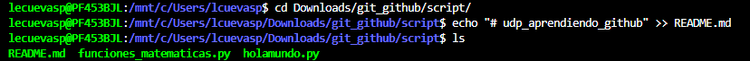

## Introducción a GitHub

### Subir archivos a Repositorio en GitHub

- Editemos el archivo README.md indicando de que se trata nuestro repositorio. Usaremos la página https://readme.so/es/editor para crear nuestro texto.

[figure not shown]

## Introducción a GitHub

### Subir archivos a Repositorio en GitHub

- Agregar nuestro archivo a Git

  ```bash
  git add README.md
  ```

- Generar commit al archivo agregado.

  ```bash
  git commit -m "primer commit en GitHub"
  ```

- Indica que la rama principal es la rama main

  ```bash
  git branch -M main
  ```

## Introducción a GitHub

### Subir archivos a Repositorio en GitHub

- Se agregue al repositorio remoto de la siguiente dirección. Si el primer código no funciona, intentamos con el segundo

  ```bash
  git remote add origin git@github.com:lecuevasp/udp_aprendiendo_github.git

  git remote set-url origin git@github.com:lecuevasp/udp_aprendiendo_github.git
  ```

- Agregar todos los archivos al repositorio remoto de GitHub.

  ```bash
  git push -u origin main
  ```

## Introducción a GitHub

### Subir archivos a Repositorio en GitHub

- Hemos cargado nuestros archivos a GitHub

[figure not shown]

## Introducción a GitHub

### Subir nuevos archivos a Repositorio en GitHub

- Para subir nuevos archivos en el mismo repositorio debemos ejecutar lo siguientes pasos:

  ```bash
  git add <nombre_archivo.extension>
  git commit m "nuevo mensaje"
  git push origin main
  ```

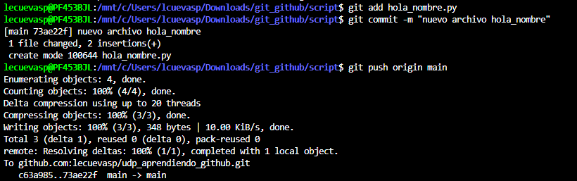

## Introducción a GitHub

### Subir archivos a Repositorio en GitHub

- Hemos cargado nuestros archivos a GitHub

[figure not shown]

## Introducción a GitHub Pages

### Publicar archivos en la Web

- Nuestros proyecto pueden er publicados gracias al servicio que ofrece GitHub Pages.
- Lo pasos para realizar la publicación son los siguiente:
  - Posicionarnos en el archivo que queremos publicar
  - Ir a *Setting* donde realizaremos el paso a paso para publicar nuestro documentos.

## Introducción a GitHub Pages

### Publicar archivos en la Web

- Seleccionar *Setting*

[figure not shown]

- Seleccionar *Pages*

[figure not shown]

## Introducción a GitHub Pages

### Publicar archivos en la Web

- En Branch seleccionar *main* y *root*

[figure not shown]

- Guardar modificacione en *Save*

[figure not shown]

[figure not shown]

Universidad Diego Portales